# P2_TrafficSignClassifier

## Project 2: Build a Traffic Sign Recognition Classifier

**Build a Traffic Sign Recognition Project**

The goals / steps of this project are the following:

- Load the data set
- Explore, summarize and visualize the data set
- Design, train and test a model architecture
- Use the model to make predictions on new images
- Analyze the softmax probabilities of the new images
- Summarize the results with a written report

```python
import matplotlib.pyplot as plt
%matplotlib inline
import numpy as np
import cv2
import math
import random
import os
import csv
import pickle
import time
import glob
from textwrap import wrap
from sklearn.utils import shuffle
import tensorflow as tf
from tensorflow.contrib.layers import flatten
```

## Step 0: Load the Data

```python
# Load pickled data
training_file = 'train.p'
validation_file = 'valid.p'
testing_file = 'test.p'

with open(training_file, mode='rb') as f:
    train = pickle.load(f)
with open(validation_file, mode='rb') as f:
    valid = pickle.load(f)
with open(testing_file, mode='rb') as f:
    test = pickle.load(f)

X_train, y_train = train['features'], train['labels']
X_valid, y_valid = valid['features'], valid['labels']
X_test, y_test = test['features'], test['labels']

assert(len(X_train) == len(y_train))
assert(len(X_valid) == len(y_valid))
assert(len(X_test) == len(y_test))
```

## Step 1: Dataset Summary & Exploration

### a) Basic Summary of the Dataset

```python
# Number of training examples
n_train = len(X_train)

# Number of validation examples
n_valid = len(X_valid)

# Number of testing examples
n_test = len(X_test)

# Shape of traffic sign image
image_shape = X_train[0].shape

# Number of unique classes/labels in the dataset
n_classes = len(np.unique(y_train))

print('---------------------------------------------')
print("Number of training examples    = ", n_train)
print("Number of validation examples  = ", n_valid)
print("Number of testing examples     = ", n_test)
print("Image data shape               = ", image_shape)
print("Number of classes              = ", n_classes)
print('---------------------------------------------')
```

```
---------------------------------------------
Number of training examples    =  34799
Number of validation examples  =  4410
Number of testing examples     =  12630
Image data shape               =  (32, 32, 3)
Number of classes              =  43
---------------------------------------------
```

### b) Plotting an Example of Each Sign Type

```python
# Extract a dictionary of sign id's and sign names from the csv
with open('signnames.csv', 'r') as f:
    sign_name_dict = dict(line.strip().split(',') for line in f.readlines()[1:])
```

```python
# Get a list of signs for each sign type
signs_by_type_train = [[ind for ind, sign_id in enumerate(y_train) if sign_id == i] for i in range(n_classes)]
signs_by_type_valid = [[ind for ind, sign_id in enumerate(y_valid) if sign_id == i] for i in range(n_classes)]
signs_by_type_test = [[ind for ind, sign_id in enumerate(y_test) if sign_id == i] for i in range(n_classes)]
```

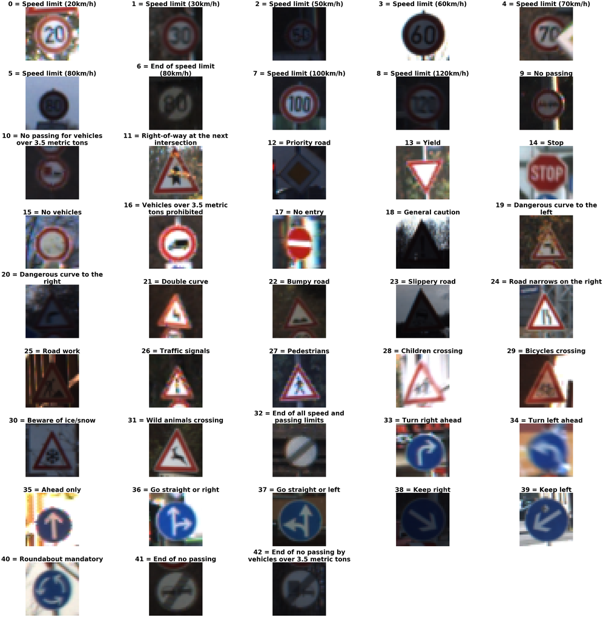

```python
# Plot an example of each sign type
plt.figure(1, figsize=(48,48))
for i in range(43):
    plt.subplot(9, 5, i+1)
    index = random.randint(min(signs_by_type_train[i]), max(signs_by_type_train[i]))
    img = X_train[index]
    plt.axis('off')
    plt.imshow(img)
    plt.title("\n".join(wrap('{0} = {1}'.format(i, sign_name_dict[str(i)]), 30)), fontsize=35, fontweight="bold")
    plt.tight_layout(pad=0., w_pad=0., h_pad=0.)
```

### c) Visualization of the Dataset

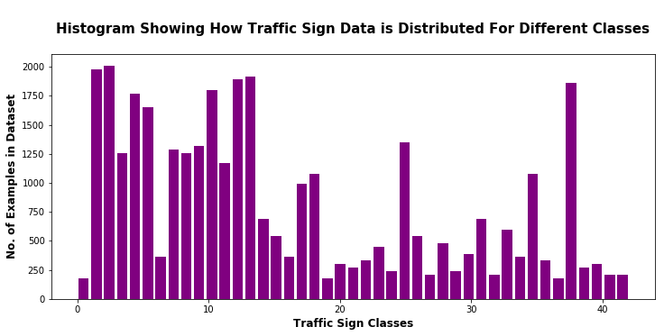

```python
# Plotting Historgam of Traffic Sign Training Dataset
hist, bins = np.histogram(y_train, bins = n_classes)
width = 0.8 * (bins[1] - bins[0])
center = (bins[:-1] + bins[1:]) / 2
plt.figure(figsize=(12,5))
plt.bar(center, hist, align = "center", width = width, facecolor = "purple")
plt.title("\nHistogram Showing How Traffic Sign Data is Distributed For Different Classes\n", fontsize=15, fontweight="bold")
plt.xlabel("Traffic Sign Classes", fontsize = 12, fontweight="bold")
plt.ylabel("No. of Examples in Dataset", fontsize = 12, fontweight="bold")
plt.show()
```

**From the above distribution plot it is clear that the data is unbalanced. Some classes have very few examples compared to other classes. This is a problem for a machine learning algorithm, because the lack of balance in the data will lead it to become biased toward the classes with more data points. We need to generate more data points for the less represented classes. Therefore, implementing different Data Augmentation techniques to increase number of examples for the less represented classes in the the training dataset.**

## Step 2: Design and Test a Model Architecture

### a) Data Augmentation

Training dataset contains some traffic signs like right turn, left turn, etc. that are either mirror images of other upon horizontal flip or signs like roundabouts, ahead only, etc. have no effect or mean entirely a different traffic sign after a 90° rotation. Such data augmentation techniques would only increase the number of examples in the dataset but not make the training effective for the classes for which examples are less in the first place. Thus, data augmentation techniques need to be chosen with care.

```python
# Scaling
def scaling(img):
    fx = random.uniform(1.0, 1.3)
    fy = random.uniform(1.0, 1.3)
    scaled = cv2.resize(img, None, fx=fx, fy=fy, interpolation = cv2.INTER_CUBIC)[0:32, 0:32,:]
    return scaled

# Traslation
def translation(img):
    rows, cols, _ = img.shape
    rY = random.randint(-5, 5)
    rX = random.randint(-5, 5)
    M = np.float32([[1,0,rY],[0,1,rX]])
    trans = cv2.warpAffine(img, M, (cols,rows))
    return trans

# Rotation
def rotation(img):
    rows, cols, _ = img.shape
    rot = random.uniform(-30,30)
    M = cv2.getRotationMatrix2D((cols/2, rows/2), rot, 1)
    rotate = cv2.warpAffine(img, M, (cols,rows))
    return rotate

# Affine Transformation
def affine_transform(img):
    rows, cols, _ = img.shape
    pts1 = np.float32([[5,5],[20,5],[5,20]])
    pts2 = np.float32([[1,10],[20,5],[10,25]])
    M = cv2.getAffineTransform(pts1,pts2)
    affine = cv2.warpAffine(img,M,(cols,rows))
    return affine

# Salt and Pepper Noise
def salt_pepper_noise(img):
    rows, cols, _ = img.shape
    salt_vs_pepper = 0.5
    amount = 0.004
    snp = img.copy()
    # Add Salt noise
    num_salt = np.ceil(amount * img.size * salt_vs_pepper)
    coords = [np.random.randint(0, i - 1, int(num_salt)) for i in img.shape]
    snp[coords] = 255
    # Add Pepper noise
    num_pepper = np.ceil(amount * img.size * (1.0 - salt_vs_pepper))
    coords = [np.random.randint(0, i - 1, int(num_pepper)) for i in img.shape]
    snp[coords] = 0
    return snp
```

**Data Augmentation Techniques - Image Smoothing**

1. Blurring
2. Gaussian Blurring
3. Median Blurring
4. Erosion
5. Dilation

```python
# 2D Convolution
def filt_2D_convol(img):
    kernel = np.ones((5,5),np.float32)/25
    convol = cv2.filter2D(img,-1,kernel)
    return convol

# Average Blurring
def bluring(img):
    blur = cv2.blur(img,(5,5))
    return blur

# Gaussian Blurring
def gaussian_bluring(img):
    gauss_blur = cv2.GaussianBlur(img,(5,5),0)
    return gauss_blur

# Median Blurring
def median_bluring(img):
    median_blur = cv2.medianBlur(img,5)
    return median_blur

#Erosion
def erosion(img):
    kernel = np.ones((5,5),np.float32)
    img_erosion = cv2.erode(img, kernel, iterations=1)
    return img_erosion

# Dilation
def dilation(img):
    kernel = np.ones((5,5),np.float32)
    img_dilation = cv2.dilate(img, kernel, iterations=1)
    return img_dilation
```

**Data Augmentation Techniques on a Sample Traffic Sign Image**

[figure not shown]

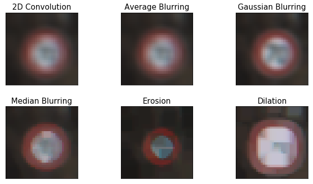

```python
# Sample Image from Training Dataset
sample_img_indx = random.randint(0, len(X_train))
sample_img = X_train[sample_img_indx]

# Applying data augmentation techniques
scaled = scaling(sample_img)
trans = translation(sample_img)
rotate = rotation(sample_img)
affine = affine_transform(sample_img)
salt_pepper = salt_pepper_noise(sample_img)
convol = filt_2D_convol(sample_img)
blur = bluring(sample_img)
gauss_blur = gaussian_bluring(sample_img)
median_blur = median_bluring(sample_img)
img_erosion = erosion(sample_img)
img_dilation = dilation(sample_img)

fig, axs = plt.subplots(2, 3, figsize=(12,6), subplot_kw={'xticks': [], 'yticks': []})
axs = axs.ravel()
fig.subplots_adjust(hspace=0.3, wspace=0.05)
axs[0].imshow(sample_img)
axs[0].set_title('Original', fontsize=15)
axs[1].imshow(scaled)
axs[1].set_title('Scaled', fontsize=15)
axs[2].imshow(trans)
axs[2].set_title('Translation', fontsize=15)
axs[3].imshow(rotate)
axs[3].set_title('Rotation', fontsize=15)
axs[4].imshow(affine)
axs[4].set_title('Affine Tranformation', fontsize=15)
axs[5].imshow(salt_pepper)
axs[5].set_title('Salt and Pepper Noise', fontsize=15)

fig, axs = plt.subplots(2, 3, figsize=(12,6), subplot_kw={'xticks': [], 'yticks': []})
axs = axs.ravel()
fig.subplots_adjust(hspace=0.3, wspace=0.05)
axs[0].imshow(convol)
axs[0].set_title('2D Convolution', fontsize=15)
axs[1].imshow(blur)
axs[1].set_title('Average Blurring', fontsize=15)
axs[2].imshow(gauss_blur)
axs[2].set_title('Gaussian Blurring', fontsize=15)
axs[3].imshow(median_blur)
axs[3].set_title('Median Blurring', fontsize=15)
axs[4].imshow(img_erosion)
axs[4].set_title('Erosion', fontsize=15)
axs[5].imshow(img_dilation)
axs[5].set_title('Dilation', fontsize=15)
```

**Data Augmentation for Training Dataset**

```python
X_train_aug = X_train
y_train_aug = y_train
print(X_train_aug.shape)
print(y_train_aug.shape)
```

```
(34799, 32, 32, 3)
(34799,)
```

```python
enable_augment = False

if enable_augment == True:
    for nClass in range(n_classes):
        class_index = np.where(y_train == nClass)
        total_samples = len(class_index[0])
        if total_samples < 800:
            for i in range(total_samples):
                scaled_trans_SnP = translation(salt_pepper_noise(scaling(X_train[class_index[0][i]])))
                rotate = rotation(X_train[class_index[0][i]])
                affine = affine_transform(X_train[class_index[0][i]])

                scaled_trans_SnP = np.reshape(scaled_trans_SnP,[1,32,32,-1])
                rotate = np.reshape(rotate,[1,32,32,-1])
                affine = np.reshape(affine,[1,32,32,-1])

                X_train_aug = np.concatenate((X_train_aug, scaled_trans_SnP), axis=0)
                y_train_aug = np.concatenate((y_train_aug,[nClass]),axis=0)
                X_train_aug = np.concatenate((X_train_aug, rotate), axis=0)
                y_train_aug = np.concatenate((y_train_aug,[nClass]),axis=0)
                X_train_aug = np.concatenate((X_train_aug, affine), axis=0)
                y_train_aug = np.concatenate((y_train_aug,[nClass]),axis=0)

    print('Dataset augmentation complete')
else:
    print('Dataset augmentation disabled. Loading saved augmented training dataset...')
```

```
Dataset augmentation disabled. Loading saved augmented training dataset...
```

```python
# Save the augmented training dataset result for later use
if enable_augment == True:
    train_aug_pickle = {}
    train_aug_pickle["features"] = X_train_aug
    train_aug_pickle["labels"] = y_train_aug
    pickle.dump(train_aug_pickle, open("train_aug.p", "wb"))
```

```python
# Load saved augmented training data
augmented_training_file = 'train_aug.p'

with open(augmented_training_file, mode='rb') as f:
    train_aug = pickle.load(f)

X_train_aug, y_train_aug = train_aug['features'], train_aug['labels']

print(X_train_aug.shape)
print(y_train_aug.shape)
```

```
(62156, 32, 32, 3)
(62156,)
```

**Comparing training dataset before and after data augmentation**

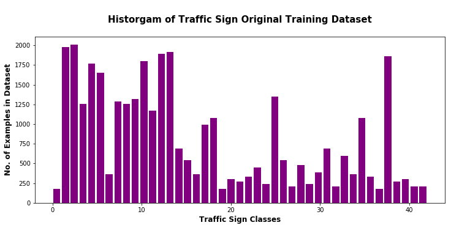

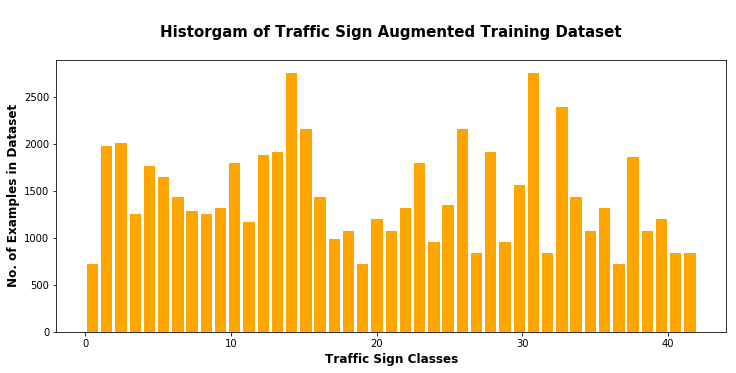

```python
# Plotting Historgam of Traffic Sign Original Training Dataset
hist, bins = np.histogram(y_train, bins = n_classes)
width = 0.8 * (bins[1] - bins[0])
center = (bins[:-1] + bins[1:]) / 2
plt.figure(figsize=(12,5))
plt.bar(center, hist, align = "center", width = width, facecolor = "purple")
plt.title("\nHistorgam of Traffic Sign Original Training Dataset\n", fontsize=15, fontweight="bold")
plt.xlabel("Traffic Sign Classes", fontsize = 12, fontweight="bold")
plt.ylabel("No. of Examples in Dataset", fontsize = 12, fontweight="bold")
plt.show()

# Plotting Historgam of Traffic Sign Augmented Training Dataset
hist_aug, bins = np.histogram(y_train_aug, bins = n_classes)
width = 0.8 * (bins[1] - bins[0])
center = (bins[:-1] + bins[1:]) / 2
hist2 = plt.figure(figsize=(12,5))
plt.bar(center, hist_aug, align = "center", width = width, facecolor = "orange")
plt.title("\nHistorgam of Traffic Sign Augmented Training Dataset\n", fontsize=15, fontweight="bold")
plt.xlabel("Traffic Sign Classes", fontsize = 12, fontweight="bold")
plt.ylabel("No. of Examples in Dataset", fontsize = 12, fontweight="bold")
plt.show()
```

**The above histogram indicates that we now have generated enough exmaples for the less represented classes in the the training dataset.**

### b) Dataset Preprocessing

Steps in dataset preprocessing include:

1. Converting an RGB to image to grayscale image reduces number of channel, thus reducing learning / processing time.
2. Normalizing the images in the dateset in the range [-1.0,1.0] to ensure that all features will have equal contribution and the algorithm converges faster.
3. Shuffling the images in dataset to reduce variance and ensure that models remain general and avoid overfitting.

**Converting RGB to Grayscale**

```python
# Convert to Grayscale
X_train_gry = np.sum(X_train_aug/3, axis=3, keepdims=True)
X_valid_gry = np.sum(X_valid/3, axis=3, keepdims=True)
X_test_gry = np.sum(X_test/3, axis=3, keepdims=True)

print('RGB training dataset shape:', X_train_aug.shape)
print('Grayscale training dataset shape:', X_train_gry.shape)
```

```
RGB training dataset shape: (62156, 32, 32, 3)
Grayscale training dataset shape: (62156, 32, 32, 1)
```

**Dataset Normalization**

```python
print('Mean of training dataset:', np.mean(X_train_gry))

# Normalize training dataset
X_train_normalized = (X_train_gry - 128)/128
X_valid_normalized = (X_valid_gry - 128)/128
X_test_normalized = (X_test_gry - 128)/128

print('Mean of training dataset after normalization:', np.mean(X_train_normalized))
```

```
Mean of training dataset: 80.0314092358
Mean of training dataset after normalization: -0.374754615345
```

**Dataset Shuffling**

```python
print('Dataset before shuffling:\n\n', y_train_aug[100:300])
```

```
Dataset before shuffling:

 [41 41 41 41 41 41 41 41 41 41 41 41 41 41 41 41 41 41 41 41 41 41 41 41 41
 41 41 41 41 41 41 41 41 41 41 41 41 41 41 41 41 41 41 41 41 41 41 41 41 41
 41 41 41 41 41 41 41 41 41 41 41 41 41 41 41 41 41 41 41 41 41 41 41 41 41
 41 41 41 41 41 41 41 41 41 41 41 41 41 41 41 41 41 41 41 41 41 41 41 41 41
 41 41 41 41 41 41 41 41 41 41 31 31 31 31 31 31 31 31 31 31 31 31 31 31 31
 31 31 31 31 31 31 31 31 31 31 31 31 31 31 31 31 31 31 31 31 31 31 31 31 31
 31 31 31 31 31 31 31 31 31 31 31 31 31 31 31 31 31 31 31 31 31 31 31 31 31
 31 31 31 31 31 31 31 31 31 31 31 31 31 31 31 31 31 31 31 31 31 31 31 31 31]
```

```python
X_train_shuf, y_train_shuf = shuffle(X_train_normalized, y_train_aug)
print('Dataset after shuffling:\n\n', y_train_shuf[100:300])
```

```
Dataset after shuffling:

 [15  9 34 18 34 30  1 17 13  7 31 36 42 41 25 21  5  1 31 28 34 29  1 39 10
 15 10 34  8 23 32 22 40  5 31  2 38 12  3 14  7 31 15 13 26 35 12 16 40 38
 24  1  7 10  2 17 37 22 34  7 37  4 12 28 38 34 16 32 21  4 14 37 14  3 28
 26  6 13 38 15 24 34 26 33 10  3  6 33 36 14 14  6 34 12 38 10 18 36 14  3
 33  5 36  9 30 23  2 25 35  5  2  2 26  6 26 35 15 23 35 27 30 28  0 27 35
 26 25 12  0 23  3  6 21  8 33 34 15 14  5 29 32 13 42 12 23 33 13 14 28 16
  1 25 30 20 15  4 11 37 11 25 31 42 28 15 32  2 14  2  5 14 14 15  2 31 26
 21 39  1 33 11  9 23 25 42  9  2 25 19  5 31 39 36  8 32 31 26 26  5 28  2]
```

### c) Model Architecture

I began by implementing the same architecture from the LeNet Lab, with no changes since my dataset is in grayscale. This model worked well enough to begin with (~93% validation accuracy).

Testing my model on new images:  
I used test images from web of three difficulty levels - Easy (very clear, well-centered, straight facing, and background noise-free signs), Medium, and Hard (signs with dirt on them, not in center of the image, perspective view, background noise, and even multiple signs in the image). For Easy images, the above model gave 100% on test accuracy. However, the model gave only 20% for Medium and 0% for Hard images.

I explored various combinations - adding convolution layers, increasing filters, running more epochs, and varying batch sizes. I was able to get higher validation accuracy but the model still gave test accuracy of only 60% for Medium and 20% for Hard images.

[figure not shown]

**VGGNet Model Architecture**

Source: https://medium.com/@siddharthdas_32104/cnns-architectures-lenet-alexnet-vgg-googlenet-resnet-and-more-666091488df5

Thus, to increase the test accuracy for Hard, I decided to go with the little advanced than LeNet that is VGGNet. My architecture is based and derived from the VGGNet. Model architecture consists of six convolutional layers and max pooling on alternate layers.

The complete architecture of the model is described in the table below:

[output not shown]

```python
EPOCHS = 20
BATCH_SIZE = 64
```

```python
def LeNet(x):
    # Hyperparameters: randomly defines variables for the weights and biases for each layer
    mu = 0
    sigma = 0.1

    # Layer 1: Convolutional. Input = 32x32x1. Output = 32x32x32.
    conv1_W = tf.Variable(tf.truncated_normal(shape=(3, 3, 1, 32), mean = mu, stddev = sigma))
    conv1_b = tf.Variable(tf.zeros(32))
    conv1   = tf.nn.conv2d(x, conv1_W, strides=[1, 1, 1, 1], padding='SAME') + conv1_b

    # Activation.
    conv1 = tf.nn.relu(conv1)

    # Pooling. Input = 32x32x32. Output = 32x32x32.
    #conv1 = tf.nn.max_pool(conv1, ksize=[1, 2, 2, 1], strides=[1, 2, 2, 1], padding='SAME')

    # Layer 2: Convolutional. Input = 32x32x32. Output = 32x32x32.
    conv2_W = tf.Variable(tf.truncated_normal(shape=(3, 3, 32, 32), mean = mu, stddev = sigma))
    conv2_b = tf.Variable(tf.zeros(32))
    conv2   = tf.nn.conv2d(conv1, conv2_W, strides=[1, 1, 1, 1], padding='SAME') + conv2_b

    # Activation.
    conv2 = tf.nn.relu(conv2)

    # Pooling. Input = 32x32x32. Output = 16x16x32.
    conv2 = tf.nn.max_pool(conv2, ksize=[1, 2, 2, 1], strides=[1, 2, 2, 1], padding='VALID')

    # Dropout.
    conv2 = tf.nn.dropout(conv2,keep_prob)

    # Layer 3: Convolutional. Input = 16x16x32. Output = 16x16x64.
    conv3_W = tf.Variable(tf.truncated_normal(shape=(3, 3, 32, 64), mean = mu, stddev = sigma))
    conv3_b = tf.Variable(tf.zeros(64))
    conv3   = tf.nn.conv2d(conv2, conv3_W, strides=[1, 1, 1, 1], padding='SAME') + conv3_b

    # Activation.
    conv3 = tf.nn.relu(conv3)

    # Pooling. Input = 16x16x64. Output = 16x16x64.
    #conv3 = tf.nn.max_pool(conv3, ksize=[1, 2, 2, 1], strides=[1, 2, 2, 1], padding='SAME')

    # Layer 4: Convolutional. Input = 16x16x64. Output = 16x16x64.
    conv4_W = tf.Variable(tf.truncated_normal(shape=(3, 3, 64, 64), mean = mu, stddev = sigma))
    conv4_b = tf.Variable(tf.zeros(64))
    conv4   = tf.nn.conv2d(conv3, conv4_W, strides=[1, 1, 1, 1], padding='SAME') + conv4_b

    # Activation.
    conv4 = tf.nn.relu(conv4)

    # Pooling. Input = 16x16x64. Output = 8x8x64.
    conv4 = tf.nn.max_pool(conv4, ksize=[1, 2, 2, 1], strides=[1, 2, 2, 1], padding='VALID')
    conv4 = tf.nn.dropout(conv4,keep_prob)

    # Layer 5: Convolutional. Input = 8x8x64 Output = 8x8x128.
    conv5_W = tf.Variable(tf.truncated_normal(shape=(3, 3, 64, 128), mean = mu, stddev = sigma))
    conv5_b = tf.Variable(tf.zeros(128))
    conv5   = tf.nn.conv2d(conv4, conv5_W, strides=[1, 1, 1, 1], padding='SAME') + conv5_b

    # Activation.
    conv5 = tf.nn.relu(conv5)

    # Pooling. Input = 8x8x128. Output = 8x8x128.
    #conv5 = tf.nn.max_pool(conv5, ksize=[1, 2, 2, 1], strides=[1, 2, 2, 1], padding='SAME')

    # Layer 6: Convolutional. Input = 8x8x128 Output = 8x8x128.
    conv6_W = tf.Variable(tf.truncated_normal(shape=(3, 3, 128, 128), mean = mu, stddev = sigma))
    conv6_b = tf.Variable(tf.zeros(128))
    conv6   = tf.nn.conv2d(conv5, conv6_W, strides=[1, 1, 1, 1], padding='SAME') + conv6_b

    # Activation.
    conv6 = tf.nn.relu(conv6)

    # Pooling. Input = 8x8x128. Output = 4x4x128.
    conv6 = tf.nn.max_pool(conv6, ksize=[1, 2, 2, 1], strides=[1, 2, 2, 1], padding='VALID')

    # Dropout.
    conv6 = tf.nn.dropout(conv6,keep_prob)

    # Flatten. Input = 4x4x128. Output = 2048.
    fc0 = flatten(conv6)

    # Layer 7: Fully Connected. Input = 2048. Output = 120.
    fc1_W = tf.Variable(tf.truncated_normal(shape=(2048, 120), mean = mu, stddev = sigma))
    fc1_b = tf.Variable(tf.zeros(120))
    fc1   = tf.matmul(fc0, fc1_W) + fc1_b

    # Activation.
    fc1 = tf.nn.relu(fc1)

    # Dropout.
    fc1 = tf.nn.dropout(fc1, keep_prob)

    # Layer 8: Fully Connected. Input = 120. Output = 120.
    fc2_W = tf.Variable(tf.truncated_normal(shape=(120, 120), mean = mu, stddev = sigma))
    fc2_b = tf.Variable(tf.zeros(120))
    fc2   = tf.matmul(fc1, fc2_W) + fc2_b

    # Activation.
    fc2 = tf.nn.relu(fc2)
    fc2 = tf.nn.dropout(fc2, keep_prob)

    # Layer 9: Fully Connected. Input = 120. Output = 43.
    fc3_W  = tf.Variable(tf.truncated_normal(shape=(120, 43), mean = mu, stddev = sigma))
    fc3_b  = tf.Variable(tf.zeros(43))
    logits = tf.matmul(fc2, fc3_W) + fc3_b

    return logits
```

```python
x = tf.placeholder(tf.float32, (None, 32, 32, 1))
y = tf.placeholder(tf.int32, (None))
keep_prob = tf.placeholder(tf.float32)
one_hot_y = tf.one_hot(y, 43)
```

**Training Pipeline**

```python
rate = 0.0009

logits = LeNet(x)
cross_entropy = tf.nn.softmax_cross_entropy_with_logits(labels=one_hot_y, logits=logits)
loss_operation = tf.reduce_mean(cross_entropy)
optimizer = tf.train.AdamOptimizer(learning_rate = rate)
training_operation = optimizer.minimize(loss_operation)
```

**Model Evaluation - Evaluate how well the loss and accuracy of the model for a given dataset.**

```python
correct_prediction = tf.equal(tf.argmax(logits, 1), tf.argmax(one_hot_y, 1))
accuracy_operation = tf.reduce_mean(tf.cast(correct_prediction, tf.float32))
saver = tf.train.Saver()

def evaluate(X_data, y_data):
    num_examples = len(X_data)
    total_accuracy = 0
    sess = tf.get_default_session()
    for offset in range(0, num_examples, BATCH_SIZE):
        batch_x, batch_y = X_data[offset:offset+BATCH_SIZE], y_data[offset:offset+BATCH_SIZE]
        accuracy = sess.run(accuracy_operation, feed_dict={x: batch_x, y: batch_y, keep_prob: 1.0})
        total_accuracy += (accuracy * len(batch_x))
    return total_accuracy / num_examples
```

**Train and validate the Model**

Steps to run the training data through the training pipeline to train the model:

- Before each epoch, shuffle the training set.
- After each epoch, measure the loss and accuracy of the validation set.

Validation dataset is used to assess how well the model is performing. A low accuracy on the training and validation sets imply underfitting. A high accuracy on the training set but low accuracy on the validation set implies overfitting.

To train the model, I used following parameters (After hundreds of tweaks!!!)

- Batch Size = 64
- Learning rate = 0.0009
- Epochs = 20
- mu = 0
- sigma = 0.1
- dropout keep prob = 0.6

```python
with tf.Session() as sess:
    sess.run(tf.global_variables_initializer())
    num_examples = len(X_train_shuf)

    print("Training...")
    print()
    for i in range(EPOCHS):
        X_train, y_train = shuffle(X_train_shuf, y_train_shuf)
        for offset in range(0, num_examples, BATCH_SIZE):
            end = offset + BATCH_SIZE
            batch_x, batch_y = X_train[offset:end], y_train[offset:end]
            sess.run(training_operation, feed_dict={x: batch_x, y: batch_y, keep_prob: 0.6})

        validation_accuracy = evaluate(X_valid_normalized, y_valid)
        print("EPOCH {} ...".format(i+1))
        print("Validation Accuracy = {:.3f}".format(validation_accuracy))
        print()

    saver.save(sess, './lenet')
    print("Model saved")
```

```
Training...

EPOCH 1 ...
Validation Accuracy = 0.292

EPOCH 2 ...
Validation Accuracy = 0.665

EPOCH 3 ...
Validation Accuracy = 0.846

EPOCH 4 ...
Validation Accuracy = 0.898

EPOCH 5 ...
Validation Accuracy = 0.943

EPOCH 6 ...
Validation Accuracy = 0.959

EPOCH 7 ...
Validation Accuracy = 0.971

EPOCH 8 ...
Validation Accuracy = 0.971

EPOCH 9 ...
Validation Accuracy = 0.980

EPOCH 10 ...
Validation Accuracy = 0.980

EPOCH 11 ...
Validation Accuracy = 0.987

EPOCH 12 ...
Validation Accuracy = 0.988

EPOCH 13 ...
Validation Accuracy = 0.989
```

[output cut: 8 more lines]

```
Validation Accuracy = 0.990

EPOCH 17 ...
Validation Accuracy = 0.992

EPOCH 18 ...
Validation Accuracy = 0.993

EPOCH 19 ...
Validation Accuracy = 0.989

EPOCH 20 ...
Validation Accuracy = 0.992

Model saved
```

**Evaluate the Model**

Once you are completely satisfied with your model, evaluate the performance of the model on the test set.

Be sure to only do this once!

If you were to measure the performance of your trained model on the test set, then improve your model, and then measure the performance of your model on the test set again, that would invalidate your test results. You wouldn't get a true measure of how well your model would perform against real data.

```python
with tf.Session() as sess:
    saver.restore(sess, tf.train.latest_checkpoint('.'))

    test_accuracy = evaluate(X_test_normalized, y_test)
    print("Test Accuracy = {:.3f}".format(test_accuracy))
```

```
Test Accuracy = 0.975
```

## Step 3: Test a Model on New Images

**Load test traffic sign images downloaded from web**

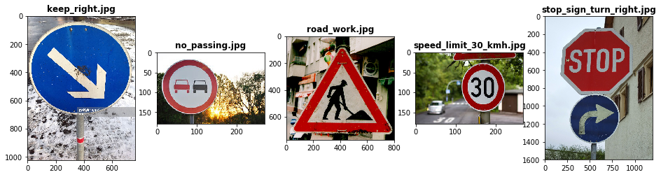

```python
testImages = glob.glob('traffic_sign_images/Hard/*.jpg')

fig, axs = plt.subplots(ncols=len(testImages), figsize=(16, 8))
axs = axs.ravel()
for i, path in enumerate(testImages):
    dirName, fileName = os.path.split(path)
    image = plt.imread(dirName + '/' + fileName)
    axs[i].imshow(image)
    #axs[i].axis('off')
    axs[i].set_title(fileName, fontweight="bold")
```

**Resizing the test traffic sign images to 32x32**

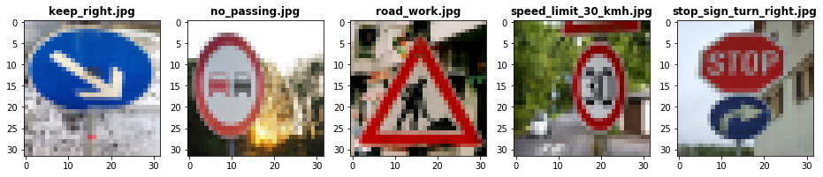

```python
#Make size of an image to 32x32.
def resized(img):
    resize = cv2.resize(img,(32, 32), interpolation = cv2.INTER_AREA)
    return resize

testImages = glob.glob('traffic_sign_images/Hard/*.jpg')

test_images = []

fig, axs = plt.subplots(ncols=len(testImages), figsize=(16, 8))
axs = axs.ravel()
for i, path in enumerate(testImages):
    dirName, fileName = os.path.split(path)
    image = plt.imread(dirName + '/' + fileName)
    image = resized(image)
    axs[i].imshow(image)
    #axs[i].axis('off')
    axs[i].set_title(fileName, fontweight="bold")
    test_images.append(image)
```

**Preprocess the test traffic sign images**

```python
test_images = np.asarray(test_images)
print(test_images.shape)
# Convert to Grayscale
test_images_gry = np.sum(test_images/3, axis=3, keepdims=True)
print(test_images_gry.shape)
# Normalization
test_images_normalized = (test_images_gry - 128)/128
print(test_images_normalized.shape)
```

```
(5, 32, 32, 3)
(5, 32, 32, 1)
(5, 32, 32, 1)
```

**Predict the Sign Type for Each Image**

```python
test_images_labels = [38, 9, 25, 1, 14]

with tf.Session() as sess:
    sess.run(tf.global_variables_initializer())
    saver3 = tf.train.import_meta_graph('./lenet.meta')
    saver3.restore(sess, "./lenet")
    my_accuracy = evaluate(test_images_normalized, test_images_labels)
    print("Test Traffic Sign Images Accuracy = {:.3f}".format(my_accuracy))
```

```
Test Traffic Sign Images Accuracy = 0.600
```

**Visualize the Softmax Probabilities**

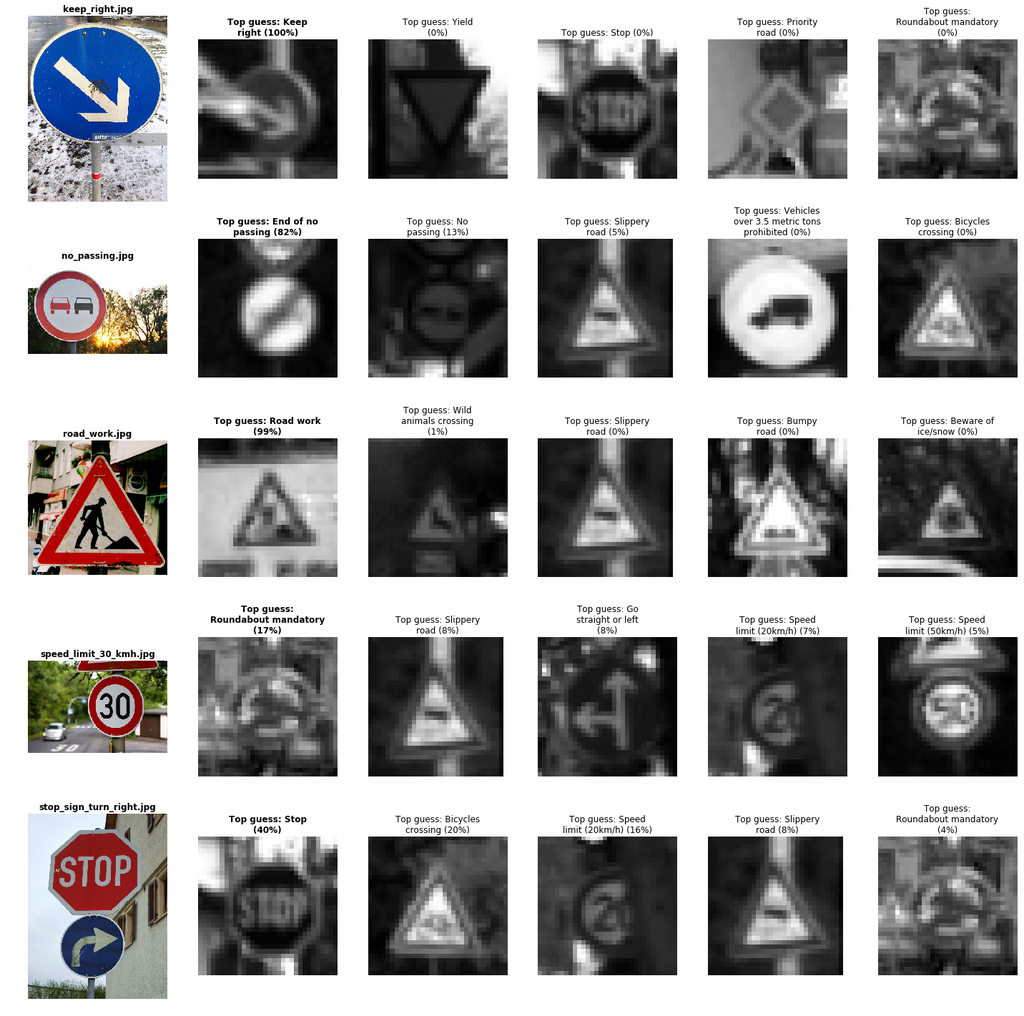

```python
softmax_logits = tf.nn.softmax(logits)
top_k = tf.nn.top_k(softmax_logits, k=5)

with tf.Session() as sess:
    sess.run(tf.global_variables_initializer())
    saver = tf.train.import_meta_graph('./lenet.meta')
    saver.restore(sess, "./lenet")
    my_softmax_logits = sess.run(softmax_logits, feed_dict={x: test_images_normalized, keep_prob: 1.0})
    my_top_k = sess.run(top_k, feed_dict={x: test_images_normalized, keep_prob: 1.0})


    fig, axs = plt.subplots(len(test_images), 6, figsize=(20, 20))
    fig.subplots_adjust(hspace = .4, wspace=.2)
    axs = axs.ravel()

    for i, path in enumerate(testImages):
        dirName, fileName = os.path.split(path)
        image = plt.imread(dirName + '/' + fileName)
        axs[6*i].axis('off')
        axs[6*i].imshow(image)
        axs[6*i].set_title(fileName, fontweight="bold")
        guess1 = my_top_k[1][i][0]
        index1 = np.argwhere(y_valid == guess1)[0]
        axs[6*i+1].axis('off')
        axs[6*i+1].imshow(X_valid_normalized[index1].squeeze(), cmap='gray')
        axs[6*i+1].set_title("\n".join(wrap('Top guess: {} ({:.0f}%)'.format(sign_name_dict[str(guess1)], 100*my_top_k[0][i][0]), 20)), fontweight="bold")
        guess2 = my_top_k[1][i][1]
        index2 = np.argwhere(y_valid == guess2)[0]
        axs[6*i+2].axis('off')
        axs[6*i+2].imshow(X_valid_normalized[index2].squeeze(), cmap='gray')
        axs[6*i+2].set_title("\n".join(wrap('Top guess: {} ({:.0f}%)'.format(sign_name_dict[str(guess2)], 100*my_top_k[0][i][1]), 20)))
        guess3 = my_top_k[1][i][2]
        index3 = np.argwhere(y_valid == guess3)[0]
        axs[6*i+3].axis('off')
        axs[6*i+3].imshow(X_valid_normalized[index3].squeeze(), cmap='gray')
        axs[6*i+3].set_title("\n".join(wrap('Top guess: {} ({:.0f}%)'.format(sign_name_dict[str(guess3)], 100*my_top_k[0][i][2]), 20)))
        guess4 = my_top_k[1][i][3]
        index4 = np.argwhere(y_valid == guess4)[0]
        axs[6*i+4].axis('off')
        axs[6*i+4].imshow(X_valid_normalized[index4].squeeze(), cmap='gray')
        axs[6*i+4].set_title("\n".join(wrap('Top guess: {} ({:.0f}%)'.format(sign_name_dict[str(guess4)], 100*my_top_k[0][i][3]), 20)))
        guess5 = my_top_k[1][i][4]
        index5 = np.argwhere(y_valid == guess5)[0]
        axs[6*i+5].axis('off')
        axs[6*i+5].imshow(X_valid_normalized[index5].squeeze(), cmap='gray')
        axs[6*i+5].set_title("\n".join(wrap('Top guess: {} ({:.0f}%)'.format(sign_name_dict[str(guess5)], 100*my_top_k[0][i][4]), 20)))
        plt.tight_layout()
```

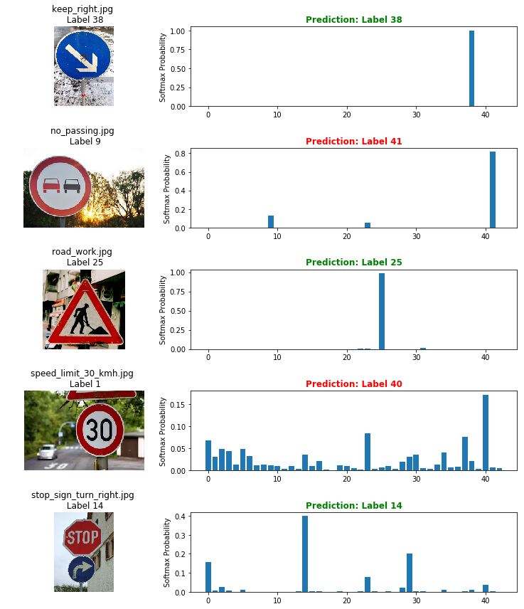

```python
fig, axs = plt.subplots(5,2, figsize=(12, 12))
axs = axs.ravel()

for i in range(len(my_softmax_logits)*2):
    if i%2 == 0:
        dirName, fileName = os.path.split(testImages[i//2])
        image = plt.imread(testImages[i//2])
        axs[i].axis('off')
        axs[i].imshow(image)
        axs[i].set_title('{} \n Label {}'.format(fileName, test_images_labels[i//2]))
    else:
        axs[i].bar(np.arange(n_classes), my_softmax_logits[(i-1)//2])
        axs[i].set_ylabel('Softmax Probability')
        if (my_top_k[1][i//2][0] == test_images_labels[i//2]):
            axs[i].set_title('Prediction: Label {}'.format(my_top_k[1][i//2][0]), color='g', fontweight='bold')
        else:
            axs[i].set_title('Prediction: Label {}'.format(my_top_k[1][i//2][0]), color='r', fontweight='bold')
    plt.tight_layout()
```